# Naive Bayesian data filtering

Marina Juzgado

2026-03-06

## Introduction and goal of the case study

In this case study, it will be showed how to apply Bayes Theorem for data filtering in order to design a detector of opinion (favourable or against death penalty) in different twits provided in the `twits.csv` dataset. The dataset is provided by the University Carlos III in the Bayesian Data Analysis course, the language of said dataset is in Spanish, working with outputs and twits in this language.

Two different points of view will be compared in the case study: 1. **Frequentist Naive Bayes Classifier**: Based in the empiric frequence of the words 2. **Bayesian Naive Bayes Classifier**: With a Laplacian smoothing to avoid the problem of null probabilities when a word does not appear in a class during training

## Data loading and preprocessing

```r
# Load the data
twits = read.csv("Twits.csv", header = TRUE, sep = ";")
twits$Text <- iconv(twits$Text, to = "UTF-8", sub = "byte")

# Transform objective variable as factor
twits$Category = as.factor(twits$Category)

table(twits$Category)
```

```
##
## AGAINST   FAVOR
##     346     384
```

## Prepare and clean the Corpus

A *corpus* is a collection of documents. We will use `tm` package to process the texts, convert everything to lowercase and remove numbers, punctuation and Spanish common words without analytical meaning

```r
library(tm)
corpus = Corpus(VectorSource(twits$Text))
inspect(corpus[1:3])
```

```
## <<SimpleCorpus>>
## Metadata:  corpus specific: 1, document level (indexed): 0
## Content:  documents: 3
##
## [1] Mientras sigamos con la doctrina Zaffaroni y el ejecutivo no tenga huevos para promover pena de muerte y tolerancia 0 seguir<85>
## [2] <93>11 Legisladores han dado luz verde para llevar al Pleno de propuesta de pena de muerte, eso ya es n<fa>mero alto<85>
## [3] <bf><bf><bf><bf>La gente que pide la reinstauraci<f3>n de la pena de muerte tiene alguna noci<f3>n sobre derechos humanos?????
```

```r
clean_corpus = tm_map(corpus, content_transformer(tolower))
clean_corpus = tm_map(clean_corpus, removeNumbers)
clean_corpus = tm_map(clean_corpus, removePunctuation)
clean_corpus = tm_map(clean_corpus, removeWords, stopwords("es"))
clean_corpus = tm_map(clean_corpus, stripWhitespace)
inspect(clean_corpus[1])
```

```
## <<SimpleCorpus>>
## Metadata:  corpus specific: 1, document level (indexed): 0
## Content:  documents: 1
##
## [1] mientras sigamos doctrina zaffaroni ejecutivo huevos promover pena muerte tolerancia seguir
```

## Visualize the Word Clouds

The best way to understand the differences between stances are the word clouds. They highlight the most frequent terms used by each group.

```r
library(wordcloud)
favor_indices = which(twits$Category == "FAVOR")
against_indices = which(twits$Category == "AGAINST")
```

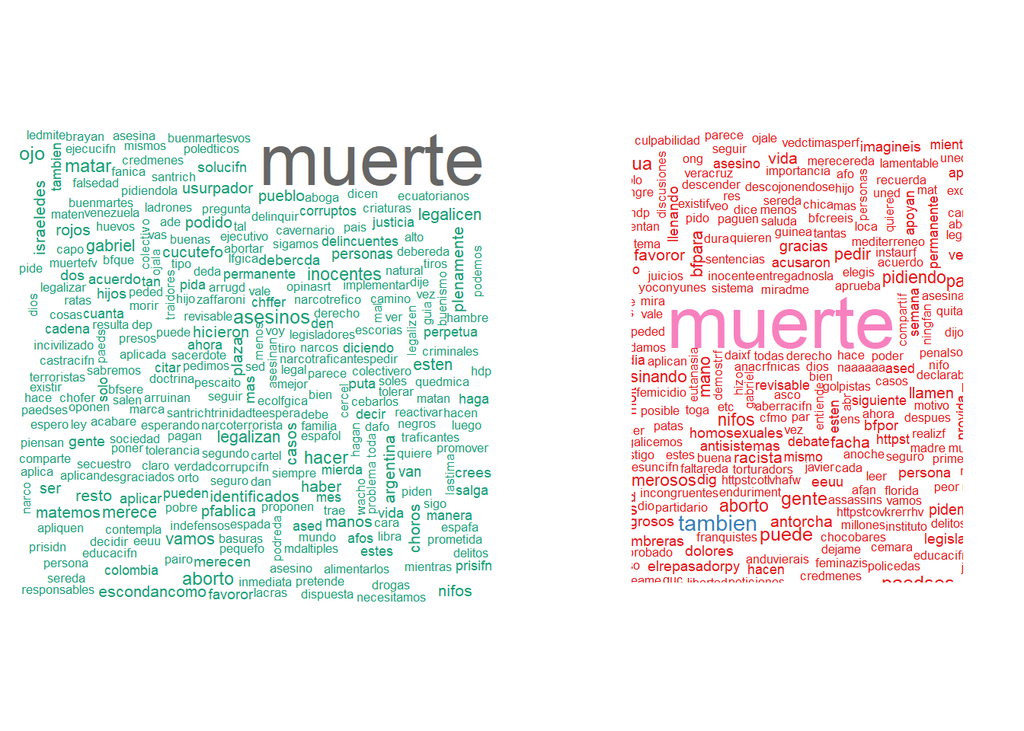

```r
par(mfrow=c(1,2))

wordcloud(clean_corpus[favor_indices], min.freq=3, scale=c(3,.5),
          colors=brewer.pal(8, "Dark2"), main="In Favor")
wordcloud(clean_corpus[against_indices], min.freq=3, scale=c(3,.5),
          colors=brewer.pal(8, "Set1"), main="Against")
```

```r
par(mfrow=c(1,1))
```

## Model preparation

Now, we need to divide the data into train and test. To divide the data, we will apply Cross Validation. This is a simple and more effective way to divide a dataset than a simple 75/25 partition to ensure results do not depend on the way the dataset is split. We will use a 5-fold Cross Validation to ensure robust results. We will extract the most frequent words from the training folds in each iteration.

```r
library(caret)
library(e1071)
set.seed(123)
```

```r
folds = createFolds(twits$Category, k = 5, returnTrain = TRUE)

# Vectors to store accuracies
acc_freq = c()
acc_bayes = c()
```

## Modeling frequentist vs bayesian approach

In the following function we will split, train and test for every of the five folds we have previously defined. First we need to divide them into train and test and create a dictionary to store the training data with the corpus to store just the words that are significant enough to let the model take a decision to classify.

Then it is important to transform the numeric counts into cathegorical ones, this is, instead of counting every time a word appears, just defining it as “Yes” or “No” appeared. This is because Naive Bayes assumes conditional independencies between features and using numbers introduces magnitude differences that could distort proability estimates.

Finally, at the end of the loop we are able to train and test the data for each fold in the Frequentist and Bayesian approach. - The Frequentist doe snot have the Laplacian correction, this means that if a word does not appear in the training, its probability is 0 so all the prediction could be null. - On the other hand, in the Bayesian approach the Laplacian correction is used, this means that we would sum 1 to every counter and avoids probability 0.

```r
for (i in 1:length(folds)) {

  # 1. Divide indexes into training and test
  train_idx = folds[[i]]
  test_idx = setdiff(1:nrow(twits), train_idx)

  # 2. Create a dictionary with the training data
  # Create matrix of the corpus
  dtm_train_complete = DocumentTermMatrix(clean_corpus[train_idx])
  # Take only the words that appear at least 5 times (the rest are not relevant enough to be taken into account)
  freq_words = findFreqTerms(dtm_train_complete, lowfreq = 5)

  # 3. Filter matrixes using those words
  dtm_train_filtered = DocumentTermMatrix(clean_corpus[train_idx],control = list(dictionary = freq_words))
  dtm_test_filtered = DocumentTermMatrix(clean_corpus[test_idx],control = list(dictionary = freq_words))

  # 4. Transform numeric counts into Yes/No as Naive Bayes works better with cathegorical variables
  train_matrix = dtm_train_filtered
  train_yesno = apply(train_matrix, 2, function(x) {
    factor(x > 0, levels = c(FALSE, TRUE), labels = c("No", "Yes"))})

  test_matrix = dtm_test_filtered
  test_yesno = apply(test_matrix, 2, function(x) {
    factor(x > 0, levels = c(FALSE, TRUE), labels = c("No", "Yes"))})

  # Extract real tags
  tag_train = twits$Category[train_idx]
  tag_test  = twits$Category[test_idx]

  # 5. TRAIN FREQUENTIST MODEL
  model_freq = naiveBayes(train_yesno, tag_train, laplace = 0)
  predictions_freq= predict(model_freq, newdata = test_yesno)
  # Compute the precision (% twits correctly classified)
  precision_freq = mean(predictions_freq == tag_test)
  acc_freq = c(acc_freq, precision_freq)

  # 6. TRAIN BAYESIAN MODEL
  model_bayes = naiveBayes(train_yesno, tag_train, laplace = 1)
  predictions_bayes = predict(model_bayes, newdata = test_yesno)
  # Compute the precision (% twits correctly classified)
  precision_bayes = mean(predictions_bayes == tag_test)
  acc_bayes = c(acc_bayes, precision_bayes)

  cat("Fold", i, "-> Frequentist Precision:", round(precision_freq, 4),
      "| Bayesian Precision:", round(precision_bayes, 4), "\n")
}
```

```
## Fold 1 -> Frequentist Precision: 0.8151 | Bayesian Precision: 0.7877
## Fold 2 -> Frequentist Precision: 0.8356 | Bayesian Precision: 0.8288
## Fold 3 -> Frequentist Precision: 0.8231 | Bayesian Precision: 0.8231
## Fold 4 -> Frequentist Precision: 0.8345 | Bayesian Precision: 0.8345
## Fold 5 -> Frequentist Precision: 0.8082 | Bayesian Precision: 0.8151
```

```r
cat("\n FINAL RESULTS \n")
```

```
##
##  FINAL RESULTS
```

```r
cat("Mean Frequentist Precision:", round(mean(acc_freq), 4), "\n")
```

```
## Mean Frequentist Precision: 0.8233
```

```r
cat("Mean Bayesian Precision:   ", round(mean(acc_bayes), 4), "\n")
```

```
## Mean Bayesian Precision:    0.8178
```

## Final conclusion

With both tests made both for Frequentist and Bayesian, we are able to see the precision results for each approach. Whereas both probabilities are similar changing only by 0.0055, the Frequentist approach has slightly more precision. This could be explained because with the +1 that the Laplace correction provides is also sum in words that sometimes do not appear in a category, there are many words in the vocabulary and even low informative words receive that +1 and change slightly the precision of the model. In other words, in this case Laplace is distorting probabilities rather than helping despite the difference between approaches is not significant.